# Practicum 3

Varshitha Uppula

```r
# Load required packages
library("stringr")
library("stringi")
library("XML")
library("methods")
library("sqldf")
library("RColorBrewer")
```

## 1. Inspect the Plant Catalog XML

The plant catalog has elements : COMMON which is the common name of a plant, BOTANICAL which is the scientific name of a plant, zone, LIGHT which is the amount of light like sunny, shade in which they grow, PRICE of the plant and AVAILABILITY. There are 36 instances of the plants.

```r
xparse <- xmlParse("plants.xml")
xparse
```

```
<?xml version="1.0"?>
<CATALOG>
  <PLANT>
    <COMMON>Bloodroot</COMMON>
    <BOTANICAL>Sanguinaria canadensis</BOTANICAL>
    <ZONE>4</ZONE>
    <LIGHT>Mostly Shady</LIGHT>
    <PRICE>$2.44</PRICE>
    <AVAILABILITY>031599</AVAILABILITY>
  </PLANT>
  <PLANT>
    <COMMON>Columbine</COMMON>
    <BOTANICAL>Aquilegia canadensis</BOTANICAL>
    <ZONE>3</ZONE>
    <LIGHT>Mostly Shady</LIGHT>
    <PRICE>$9.37</PRICE>
    <AVAILABILITY>030699</AVAILABILITY>
  </PLANT>
  <PLANT>
    <COMMON>Marsh Marigold</COMMON>
    <BOTANICAL>Caltha palustris</BOTANICAL>
    <ZONE>4</ZONE>
    <LIGHT>Mostly Sunny</LIGHT>
    <PRICE>$6.81</PRICE>
    <AVAILABILITY>051799</AVAILABILITY>
  </PLANT>
  <PLANT>
    <COMMON>Cowslip</COMMON>
    <BOTANICAL>Caltha palustris</BOTANICAL>
    <ZONE>4</ZONE>
    <LIGHT>Mostly Shady</LIGHT>
    <PRICE>$9.90</PRICE>
    <AVAILABILITY>030699</AVAILABILITY>
  </PLANT>
  <PLANT>
    <COMMON>Dutchman's-Breeches</COMMON>
    <BOTANICAL>Dicentra cucullaria</BOTANICAL>
    <ZONE>3</ZONE>
    <LIGHT>Mostly Shady</LIGHT>
    <PRICE>$6.44</PRICE>
```

[output cut: 236 more lines]

```
    <BOTANICAL>Cimicifuga</BOTANICAL>
    <ZONE>Annual</ZONE>
    <LIGHT>Shade</LIGHT>
    <PRICE>$5.63</PRICE>
    <AVAILABILITY>071199</AVAILABILITY>
  </PLANT>
  <PLANT>
    <COMMON>Cardinal Flower</COMMON>
    <BOTANICAL>Lobelia cardinalis</BOTANICAL>
    <ZONE>2</ZONE>
    <LIGHT>Shade</LIGHT>
    <PRICE>$3.02</PRICE>
    <AVAILABILITY>022299</AVAILABILITY>
  </PLANT>
</CATALOG>
```

## 2.Load the Plant Catalog XML directly into a dataframe using xmlToDataFrame.

```r
xmldata <- xmlToDataFrame("plants.xml")
print(xmldata)
```

| COMMON | BOTANICAL | ZONE | LIGHT | PRICE | AVAILABILITY |
| --- | --- | --- | --- | --- | --- |
| Bloodroot | Sanguinaria canadensis | 4 | Mostly Shady | $2.44 | 031599 |
| Columbine | Aquilegia canadensis | 3 | Mostly Shady | $9.37 | 030699 |
| Marsh Marigold | Caltha palustris | 4 | Mostly Sunny | $6.81 | 051799 |
| Cowslip | Caltha palustris | 4 | Mostly Shady | $9.90 | 030699 |
| Dutchman's-Breeches | Dicentra cucullaria | 3 | Mostly Shady | $6.44 | 012099 |
| Ginger, Wild | Asarum canadense | 3 | Mostly Shady | $9.03 | 041899 |
| Hepatica | Hepatica americana | 4 | Mostly Shady | $4.45 | 012699 |
| Liverleaf | Hepatica americana | 4 | Mostly Shady | $3.99 | 010299 |
| Jack-In-The-Pulpit | Arisaema triphyllum | 4 | Mostly Shady | $3.23 | 020199 |
| Mayapple | Podophyllum peltatum | 3 | Mostly Shady | $2.98 | 060599 |

[output cut: 26 more lines]

## 3.Create a new column retail that is a numeric column and has the data from the price column; note that the price column is text and contains a leading ‘$’ and needs to be parsed properly.

```r
prc<-str_sub(xmldata$PRICE,2)
print(prc)
```

```
 [1] "2.44" "9.37" "6.81" "9.90" "6.44" "9.03" "4.45" "3.99" "3.23" "2.98" "2.80" "5.59" "6.59" "3.90"
[15] "3.20" "9.04" "6.94" "9.58" "8.86" "9.16" "4.59" "7.16" "9.80" "2.57" "9.34" "2.78" "7.06" "6.56"
[29] "7.81" "8.56" "9.26" "4.36" "7.89" "8.60" "5.63" "3.02"
```

```r
xmldata$RETAIL <- as.numeric(prc)
print(xmldata)
```

| COMMON | BOTANICAL | ZONE | LIGHT | PRICE | AVAILABILITY | RETAIL |
| --- | --- | --- | --- | --- | --- | --- |
| Bloodroot | Sanguinaria canadensis | 4 | Mostly Shady | $2.44 | 031599 | 2.44 |
| Columbine | Aquilegia canadensis | 3 | Mostly Shady | $9.37 | 030699 | 9.37 |
| Marsh Marigold | Caltha palustris | 4 | Mostly Sunny | $6.81 | 051799 | 6.81 |
| Cowslip | Caltha palustris | 4 | Mostly Shady | $9.90 | 030699 | 9.90 |
| Dutchman's-Breeches | Dicentra cucullaria | 3 | Mostly Shady | $6.44 | 012099 | 6.44 |
| Ginger, Wild | Asarum canadense | 3 | Mostly Shady | $9.03 | 041899 | 9.03 |
| Hepatica | Hepatica americana | 4 | Mostly Shady | $4.45 | 012699 | 4.45 |
| Liverleaf | Hepatica americana | 4 | Mostly Shady | $3.99 | 010299 | 3.99 |
| Jack-In-The-Pulpit | Arisaema triphyllum | 4 | Mostly Shady | $3.23 | 020199 | 3.23 |
| Mayapple | Podophyllum peltatum | 3 | Mostly Shady | $2.98 | 060599 | 2.98 |

[output cut: 26 more lines]

## 4.Remove the original price column (the one that is text) from the dataframe.

```r
xmldata$PRICE <- NULL
xmldata
```

| COMMON | BOTANICAL | ZONE | LIGHT | AVAILABILITY | RETAIL |
| --- | --- | --- | --- | --- | --- |
| Bloodroot | Sanguinaria canadensis | 4 | Mostly Shady | 031599 | 2.44 |
| Columbine | Aquilegia canadensis | 3 | Mostly Shady | 030699 | 9.37 |
| Marsh Marigold | Caltha palustris | 4 | Mostly Sunny | 051799 | 6.81 |
| Cowslip | Caltha palustris | 4 | Mostly Shady | 030699 | 9.90 |
| Dutchman's-Breeches | Dicentra cucullaria | 3 | Mostly Shady | 012099 | 6.44 |
| Ginger, Wild | Asarum canadense | 3 | Mostly Shady | 041899 | 9.03 |
| Hepatica | Hepatica americana | 4 | Mostly Shady | 012699 | 4.45 |
| Liverleaf | Hepatica americana | 4 | Mostly Shady | 010299 | 3.99 |
| Jack-In-The-Pulpit | Arisaema triphyllum | 4 | Mostly Shady | 020199 | 3.23 |
| Mayapple | Podophyllum peltatum | 3 | Mostly Shady | 060599 | 2.98 |

[output cut: 26 more lines]

## 5.Update all prices: increase them by 4.25%.

```r
 prc<- xmldata$RETAIL
prc <- prc+(prc * 0.0425)
xmldata$RETAIL <- prc
print(xmldata)
```

| COMMON | BOTANICAL | ZONE | LIGHT | AVAILABILITY | RETAIL |
| --- | --- | --- | --- | --- | --- |
| Bloodroot | Sanguinaria canadensis | 4 | Mostly Shady | 031599 | 2.543700 |
| Columbine | Aquilegia canadensis | 3 | Mostly Shady | 030699 | 9.768225 |
| Marsh Marigold | Caltha palustris | 4 | Mostly Sunny | 051799 | 7.099425 |
| Cowslip | Caltha palustris | 4 | Mostly Shady | 030699 | 10.320750 |
| Dutchman's-Breeches | Dicentra cucullaria | 3 | Mostly Shady | 012099 | 6.713700 |
| Ginger, Wild | Asarum canadense | 3 | Mostly Shady | 041899 | 9.413775 |
| Hepatica | Hepatica americana | 4 | Mostly Shady | 012699 | 4.639125 |
| Liverleaf | Hepatica americana | 4 | Mostly Shady | 010299 | 4.159575 |
| Jack-In-The-Pulpit | Arisaema triphyllum | 4 | Mostly Shady | 020199 | 3.367275 |
| Mayapple | Podophyllum peltatum | 3 | Mostly Shady | 060599 | 3.106650 |

[output cut: 26 more lines]

## 6.Create a histogram of the number of plants by price.

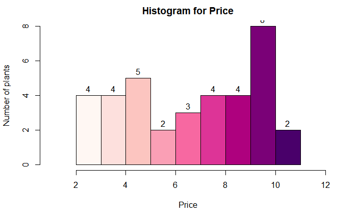

```r
price<- xmldata$RETAIL
darkcol <- brewer.pal(9, "RdPu")
hist(price,main="Histogram for Price",
     xlab="Price",
     ylab="Number of plants",
     xlim=c(1,12),
     col= darkcol,
     labels = TRUE)
```

## 7.Using sqldf create a SQL query that finds the common names of all plants that cost less than $8 and grow in Sunny light.

```r
query1<- sqldf("select COMMON from xmldata where Retail<8 AND LIGHT = 'Sunny'")
print(query1)
```

| COMMON |
| --- |
| Butterfly Weed |
| Primrose |

## 8.Using either sqldf or dataframe functions, how many plants grow in full shade?

```r
query2<- sqldf("select count(*) from xmldata where LIGHT = 'Shade'")
print(query2)
```

| count(*) |
| --- |
| 12 |

## 9.Write the dataframe to a new table in a new SQLite database using the dbWriteTable function.

```r
con <- dbConnect(SQLite(),dbname="prac3.db")
dbWriteTable(con,overwrite =TRUE, "plants", xmldata)
dbReadTable(con, "plants")
```

| COMMON | BOTANICAL | ZONE | LIGHT | AVAILABILITY | RETAIL |
| --- | --- | --- | --- | --- | --- |
| Bloodroot | Sanguinaria canadensis | 4 | Mostly Shady | 031599 | 2.543700 |
| Columbine | Aquilegia canadensis | 3 | Mostly Shady | 030699 | 9.768225 |
| Marsh Marigold | Caltha palustris | 4 | Mostly Sunny | 051799 | 7.099425 |
| Cowslip | Caltha palustris | 4 | Mostly Shady | 030699 | 10.320750 |
| Dutchman's-Breeches | Dicentra cucullaria | 3 | Mostly Shady | 012099 | 6.713700 |
| Ginger, Wild | Asarum canadense | 3 | Mostly Shady | 041899 | 9.413775 |
| Hepatica | Hepatica americana | 4 | Mostly Shady | 012699 | 4.639125 |
| Liverleaf | Hepatica americana | 4 | Mostly Shady | 010299 | 4.159575 |
| Jack-In-The-Pulpit | Arisaema triphyllum | 4 | Mostly Shady | 020199 | 3.367275 |
| Mayapple | Podophyllum peltatum | 3 | Mostly Shady | 060599 | 3.106650 |

[output cut: 26 more lines]

```r
dbDisconnect(con)
```

# In SQLite:

## 1.Inspect the database created in (9) above. Is the table there? What is its name? Are the columns correct?

TABLE plants is created in the database prac3, all the columns given in the XML are present as shown in the below figures. On inspection of the table, we can see that the data types of columns COMMON,BOTANICAL,ZONE,LIGHT,AVAILABILTY is TEXT and for RETAIL it is REAL.

[figure not shown]

Fig : Database prac3 created

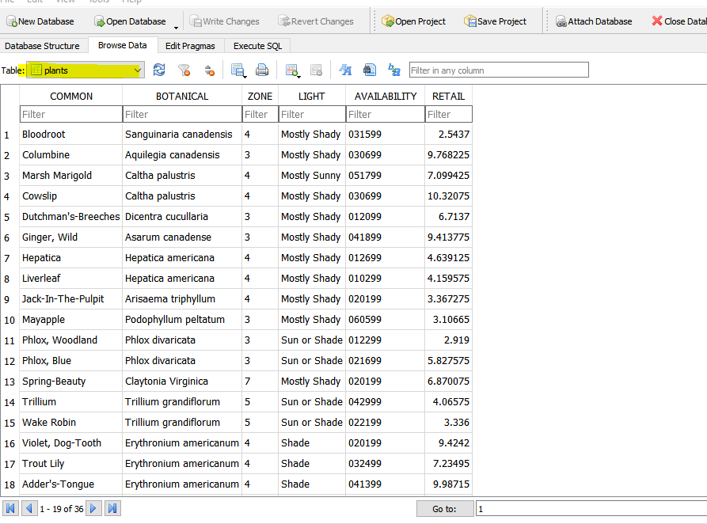

Fig : Table created in sqlite

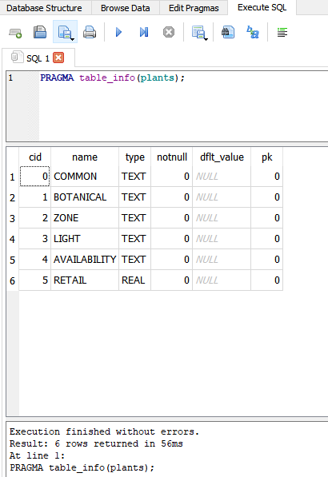

Fig : Data Types of the columns in table plants

## 2.Write a SQL UPDATE statement that decreases all prices by 0.75%.

UPDATE plants SET RETAIL = RETAIL -( RETAIL * 0.0075);

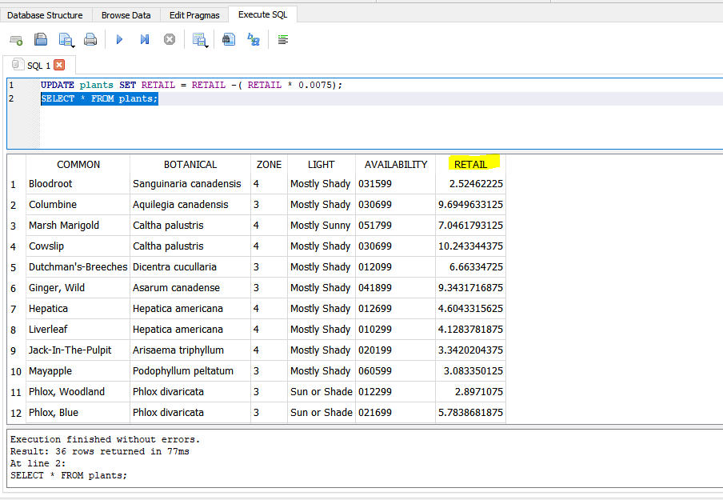

# In R Studio

## 1.Connect to the SQLite database from above

```r
con <- dbConnect(SQLite(),dbname="prac3.db")
dbReadTable(con, "plants")
```

| COMMON | BOTANICAL | ZONE | LIGHT | AVAILABILITY | RETAIL |
| --- | --- | --- | --- | --- | --- |
| Bloodroot | Sanguinaria canadensis | 4 | Mostly Shady | 031599 | 2.524622 |
| Columbine | Aquilegia canadensis | 3 | Mostly Shady | 030699 | 9.694963 |
| Marsh Marigold | Caltha palustris | 4 | Mostly Sunny | 051799 | 7.046179 |
| Cowslip | Caltha palustris | 4 | Mostly Shady | 030699 | 10.243344 |
| Dutchman's-Breeches | Dicentra cucullaria | 3 | Mostly Shady | 012099 | 6.663347 |
| Ginger, Wild | Asarum canadense | 3 | Mostly Shady | 041899 | 9.343172 |
| Hepatica | Hepatica americana | 4 | Mostly Shady | 012699 | 4.604332 |
| Liverleaf | Hepatica americana | 4 | Mostly Shady | 010299 | 4.128378 |
| Jack-In-The-Pulpit | Arisaema triphyllum | 4 | Mostly Shady | 020199 | 3.342020 |
| Mayapple | Podophyllum peltatum | 3 | Mostly Shady | 060599 | 3.083350 |

[output cut: 26 more lines]

## 2.Build and execute a SQL query that finds the number of plants by light.

```r
dbGetQuery(con, "SELECT count(*), LIGHT FROM plants GROUP BY LIGHT")
```

| count(*) | LIGHT |
| --- | --- |
| 13 | Mostly Shady |
| 1 | Mostly Sunny |
| 12 | Shade |
| 1 | Sun |
| 6 | Sun or Shade |
| 3 | Sunny |

```r
dbDisconnect(con)
```

# In R Studio

## 1.Parse the Plant Catalog XML and write an XPath query that finds all plants that grow in full shade or in full sun.

```r
doc<- xmlParse("plants.xml")
xpathquery<- xpathSApply(doc,"/CATALOG/PLANT[LIGHT='Sun'or LIGHT ='Shade']")
xpathquery
```

```
[[1]]
<PLANT>
  <COMMON>Violet, Dog-Tooth</COMMON>
  <BOTANICAL>Erythronium americanum</BOTANICAL>
  <ZONE>4</ZONE>
  <LIGHT>Shade</LIGHT>
  <PRICE>$9.04</PRICE>
  <AVAILABILITY>020199</AVAILABILITY>
</PLANT>

[[2]]
<PLANT>
  <COMMON>Trout Lily</COMMON>
  <BOTANICAL>Erythronium americanum</BOTANICAL>
  <ZONE>4</ZONE>
  <LIGHT>Shade</LIGHT>
  <PRICE>$6.94</PRICE>
  <AVAILABILITY>032499</AVAILABILITY>
</PLANT>

[[3]]
<PLANT>
  <COMMON>Adder's-Tongue</COMMON>
  <BOTANICAL>Erythronium americanum</BOTANICAL>
  <ZONE>4</ZONE>
  <LIGHT>Shade</LIGHT>
  <PRICE>$9.58</PRICE>
  <AVAILABILITY>041399</AVAILABILITY>
</PLANT>

[[4]]
<PLANT>
  <COMMON>Bee Balm</COMMON>
  <BOTANICAL>Monarda didyma</BOTANICAL>
  <ZONE>4</ZONE>
  <LIGHT>Shade</LIGHT>
  <PRICE>$4.59</PRICE>
  <AVAILABILITY>050399</AVAILABILITY>
</PLANT>

```

[output cut: 74 more lines]

```
  <ZONE>Annual</ZONE>
  <LIGHT>Shade</LIGHT>
  <PRICE>$5.63</PRICE>
  <AVAILABILITY>071199</AVAILABILITY>
</PLANT>

[[13]]
<PLANT>
  <COMMON>Cardinal Flower</COMMON>
  <BOTANICAL>Lobelia cardinalis</BOTANICAL>
  <ZONE>2</ZONE>
  <LIGHT>Shade</LIGHT>
  <PRICE>$3.02</PRICE>
  <AVAILABILITY>022299</AVAILABILITY>
</PLANT>
```

## 2.Put the result from the previous XPath query into a dataframe and then calculate the 10% trimmed mean of the prices.

```r
df<-xmlToDataFrame(xpathquery)
df
```

| COMMON | BOTANICAL | ZONE | LIGHT | PRICE | AVAILABILITY |
| --- | --- | --- | --- | --- | --- |
| Violet, Dog-Tooth | Erythronium americanum | 4 | Shade | $9.04 | 020199 |
| Trout Lily | Erythronium americanum | 4 | Shade | $6.94 | 032499 |
| Adder's-Tongue | Erythronium americanum | 4 | Shade | $9.58 | 041399 |
| Bee Balm | Monarda didyma | 4 | Shade | $4.59 | 050399 |
| Bergamot | Monarda didyma | 4 | Shade | $7.16 | 042799 |
| Buttercup | Ranunculus | 4 | Shade | $2.57 | 061099 |
| Crowfoot | Ranunculus | 4 | Shade | $9.34 | 040399 |
| Cinquefoil | Potentilla | Annual | Shade | $7.06 | 052599 |
| Jacob's Ladder | Polemonium caeruleum | Annual | Shade | $9.26 | 022199 |
| Greek Valerian | Polemonium caeruleum | Annual | Shade | $4.36 | 071499 |

[output cut: 3 more lines]

```r
mean(as.numeric(substring(df$PRICE,2)), trim=0.1)
```

```
[1] 6.753636
```